# progetto_air_crashes

```python
# Carichiamo il dataset e visualizziamo qualcosa
import pandas as pd
import numpy as np
import plotly.offline as py
import plotly.graph_objs as go
from matplotlib import pyplot as plt
import datetime

import warnings
warnings.filterwarnings("ignore", category=UserWarning)

py.init_notebook_mode(connected=True)

dataset = pd.read_csv("Airplane_Crashes_and_Fatalities_Since_1908_20190820105639.csv")
np.random.seed(42)
obs, feat = dataset.shape
dataset.sample(5)
print(str(str(obs) + " osservazioni (crashes) e " + str(feat) + " attributi"))
```

```
4967 osservazioni (crashes) e 17 attributi
```

```python
dataset.describe()
```

|  | Aboard | Aboard Passangers | Aboard Crew | Fatalities | Fatalities Passangers | Fatalities Crew | Ground |
| --- | --- | --- | --- | --- | --- | --- | --- |
| count | 4950.000000 | 4739.000000 | 4742.000000 | 4959.000000 | 4725.000000 | 4726.000000 | 4926.000000 |
| mean | 31.082626 | 26.893437 | 4.478912 | 22.338173 | 19.017566 | 3.579348 | 1.728177 |
| std | 45.435446 | 44.007432 | 3.489019 | 35.026176 | 34.114849 | 3.170223 | 55.708966 |
| min | 0.000000 | 0.000000 | 0.000000 | 0.000000 | 0.000000 | 0.000000 | 0.000000 |
| 25% | 7.000000 | 3.000000 | 2.000000 | 4.000000 | 1.000000 | 2.000000 | 0.000000 |
| 50% | 16.000000 | 12.000000 | 4.000000 | 11.000000 | 8.000000 | 3.000000 | 0.000000 |
| 75% | 35.000000 | 30.000000 | 6.000000 | 25.000000 | 21.000000 | 5.000000 | 0.000000 |
| max | 644.000000 | 614.000000 | 61.000000 | 583.000000 | 560.000000 | 46.000000 | 2750.000000 |

```python
# changing the datatype of "Date" column from string type to datetime datatype
dataset["Date"]= pd.to_datetime(dataset["Date"])

#changing the datatype of "Time" column from string to datetime format
def make_datetime(x):
    try:
        return datetime.datetime.strptime(x, '%H:%M').time()
    except:
        return np.nan

dataset["Time"] = dataset["Time"].apply(make_datetime)
```

```python
# Extracting the year, month and day out of the Date column
dataset["Year"] = dataset["Date"].apply(lambda x: x.year)
dataset["Month"] = dataset["Date"].apply(lambda x: x.month)
dataset["Day"] = dataset["Date"].apply(lambda x: x.day)

# dropping null columns for this analysis
dataset_time = dataset.dropna(subset=["Time"])

# Extracting the hour out of the time column
dataset_time["Hour"] = dataset_time["Time"].apply(lambda x: x.hour)
```

[output not shown]

## 1.1 Incidenti aerei per anno, mese e giorno

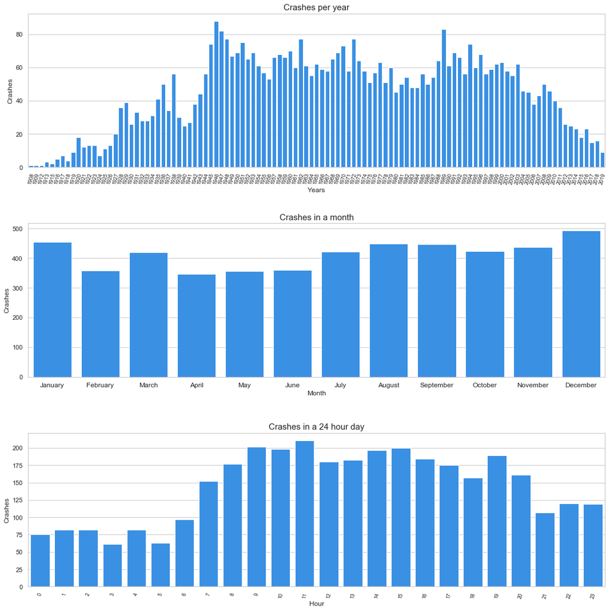

```python
import seaborn as sns
sns.set(style="whitegrid")
sns.set_color_codes("pastel")

crashes_year = dataset["Year"].value_counts().sort_index()
crashes_hour = dataset_time["Hour"].value_counts().sort_index()
crashes_month = dataset["Month"].value_counts().sort_index()

#Crashes per year
fig = plt.figure(figsize=(15,15))
ax1 = fig.add_subplot(3,1,1)
sns.barplot(x=crashes_year.index,y=crashes_year.values,ax=ax1,color='#1E90FF')
ax1.set(ylabel="Crashes",xlabel="Years")
ax1.set_title("Crashes per year",fontsize=15)
ax1.set_xticklabels(crashes_year.index,rotation=75,fontsize=9)

#Crashes per month
months = ["January","February","March","April","May", "June", "July","August","September","October","November","December"]

ax2 = fig.add_subplot(3,1,2)
sns.barplot(x=crashes_month.index,y=crashes_month.values,ax=ax2,color='#1E90FF')
ax2.set(ylabel="Crashes",xlabel="Month")
ax2.set_title("Crashes in a month",fontsize=15)
ax2.set_xticklabels(months,fontsize=12)

#Crashes per hour
ax3 = fig.add_subplot(3,1,3)
sns.barplot(x=crashes_hour.index,y=crashes_hour.values,ax=ax3,color='#1E90FF')
ax3.set(ylabel="Crashes",xlabel="Hour")
ax3.set_title("Crashes in a 24 hour day",fontsize=15)
ax3.set_xticklabels(crashes_hour.index,rotation=75,fontsize=9)


plt.tight_layout(w_pad=4, h_pad=3)
plt.show()
```

#### Osservazioni

```python
data = [go.Scatter(x=crashes_year.index,
                   y=crashes_year.values,
                   mode = 'lines+markers'
                   )]
layout = go.Layout(title="Airplanes Crashes 1908 to 30-07-2019",
                   xaxis=dict(title="Year",),
                   yaxis=dict(title="Crashes"),
                   font=dict(size=16))
fig = go.Figure(data, layout)
py.iplot(fig)
```

[interactive chart not shown]

## 1.2 Incidenti aerei per anno, separati per incidenti militari e civili

```python
#incidenti per anno,separati per incidenti militari e civili
crashes_year_military = dataset[dataset['Operator'].str.contains('Military', regex=False, na=False)]
crashes_year_civilian = dataset[dataset['Operator'].str.contains('Military')==False]
crashes_year_military = crashes_year_military['Year'].value_counts().sort_index()
crashes_year_civilian = crashes_year_civilian['Year'].value_counts().sort_index()

data = [
    go.Bar(name='Military', x=crashes_year_military.index, y = crashes_year_military.values),
    go.Bar(name='Civilian', x=crashes_year_civilian.index, y = crashes_year_civilian.values)
]

layout = go.Layout(title="Airplanes Crashes from 1908 to 30-07-2019",xaxis=dict(title="Year",),yaxis=dict(title="Crashes"), font=dict(size=16))
fig = go.Figure(data, layout)
fig.update_layout(barmode='stack')
py.iplot(fig)

data = [
    go.Scatter(name='Military', x=crashes_year_military.index,y=crashes_year_military.values, mode = 'lines+markers'),
    go.Scatter(name='Civilian', x=crashes_year_civilian.index,y=crashes_year_civilian.values, mode = 'lines+markers')
]

layout = go.Layout(title="Airplanes Crashes from 1908 to 30-07-2019",xaxis=dict(title="Year",),yaxis=dict(title="Crashes"),font=dict(size=16))
fig = go.Figure(data, layout)
py.iplot(fig)
```

[interactive chart not shown]

Gli incidenti di aerei militari risultano verificati meno di quelli civili, gli aerei militari sono più robusti e crashano di meno? Oppure non tutti gli incidenti militari vengono annunciati

## 2.1 Numero di morti a causa degli incidenti aerei per anno

Partendo dai dati delle vittime e di quelli che erano a bordo, possiamo calcolare il numero di persone sopravissute per ogni incidente. Sostituisco anche i valori non numerici nella colonna creata 'Survived' con il valore 0.

```python
# dropping null values from Aboard and Fatalities columns and see if there are any outliers (like Fatalities being
# greater than Aboard)
dataset[["Aboard","Fatalities"]].dropna()[dataset["Fatalities"] > dataset["Aboard"]]
dataset['Survived'] = dataset['Aboard'] - dataset['Fatalities']
dataset['Survived'].fillna(0, inplace = True)
```

```python
aboard_fatalities = dataset.pivot_table(values=["Aboard","Fatalities","Survived"],index="Year",aggfunc=np.sum)

data = [
    go.Bar(name='Survived', x=aboard_fatalities["Survived"].index, y = aboard_fatalities["Survived"].values),
    go.Bar(name='Fatalities', x=aboard_fatalities["Fatalities"].index, y = aboard_fatalities["Fatalities"].values)
]

layout = go.Layout(title="Fatalities and survived in the crashes by year",
                   xaxis=dict(title="Year"),
                   yaxis=dict(title="Survived - Fatalities"),
                   font=dict(size=14))
fig = go.Figure(data, layout)
fig.update_layout(barmode='stack')
py.iplot(fig)

aboard_fatalities['Proportion'] = aboard_fatalities['Fatalities'] / aboard_fatalities['Aboard']

data = [
    go.Scatter(name='Aboard', x=aboard_fatalities["Aboard"].index, y = aboard_fatalities["Aboard"].values, fill='tozeroy'),
    go.Scatter(name='Fatalities', x=aboard_fatalities["Fatalities"].index, y = aboard_fatalities["Fatalities"].values,fill='tozeroy')
]

layout = go.Layout(title="Persons involved in the crashes by year",
                   xaxis=dict(title="Year"),
                   yaxis=dict(title="Number of persons"),
                   font=dict(size=14))
fig = go.Figure(data, layout)
py.iplot(fig)
```

[interactive chart not shown]

## 2.2 Fatalities ratio

Il rapporto fra il numero di vittime ed il numero complessivo di tutte le persone saliti a bordo di un aereo incidentato.

```python
aboard_fatalities['Proportion'] = aboard_fatalities['Fatalities'] / aboard_fatalities['Aboard']
```

```python
data = [
    go.Scatter(x=aboard_fatalities["Proportion"].index, y = aboard_fatalities["Proportion"].values, mode = 'lines+markers')
]

layout = go.Layout(title="Fatalities ratio by year",xaxis=dict(title="Year",),yaxis=dict(title="Ratio"),font=dict(size=14))
fig = go.Figure(data, layout)
py.iplot(fig)
```

[interactive chart not shown]

## 3.1 Correlazione fra le variabili

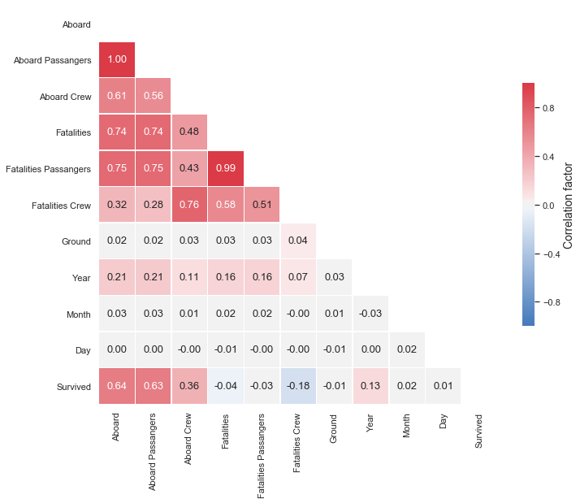

```python
corr = dataset.corr()
# Generate a mask for the upper triangle
mask = np.zeros_like(corr, dtype=np.bool)
mask[np.triu_indices_from(mask)] = True

# Set up the matplotlib figure
f, ax = plt.subplots(figsize=(11, 11))

sns.set(style="white")
# Generate a custom diverging colormap
cmap = sns.diverging_palette(250, 10, as_cmap=True)
# Draw the heatmap with the mask and correct aspect ratio
ax= sns.heatmap(corr, mask=mask, cmap=cmap, vmax=1.0,vmin=-1.0, annot = True,
            center=0,square=True, linewidths=.5, cbar_kws={"shrink": .5,'label': 'Correlation factor'},
                fmt=".2f", annot_kws={'size':13}
          )
ax.figure.axes[-1].yaxis.label.set_size(14)
```

## 4.1 Analisi delle compagne aeree coinvolte negli incidenti

```python
dataset.Operator = dataset.Operator.str.upper()
# Mergiare tutti gli operatori che appartengono a USA ARMY.
dataset.Operator.loc[(dataset["Operator"] == 'MILITARY - U.S. ARMY AIR FORCES')] = 'MILITARY - U.S. AIR FORCE'
dataset.Operator.loc[(dataset["Operator"] == 'MILITARY - U.S. ARMY')] = 'MILITARY - U.S. AIR FORCE'
dataset.Operator.loc[(dataset["Operator"] == 'MILITARY - U.S. NAVY')] = 'MILITARY - U.S. AIR FORCE'

# Ragruppa gli operatori
Total_by_Op = dataset.groupby('Operator')[['Operator']].count()
Total_by_Op = Total_by_Op.rename(columns={"Operator": "Count"})
Total_by_Op = Total_by_Op.sort_values(by='Count', ascending=False).head(15)
total = Total_by_Op['Count'].sum()

Total_by_Op['Percentage'] = round((Total_by_Op['Count'] /total) * 100, 2)
Total_by_Op['Percentage'] = Total_by_Op['Percentage'].astype(str) + " %"

values = list(range(19))

data = [
    go.Bar(y=Total_by_Op["Count"].index,
           x = Total_by_Op["Count"],
           text= Total_by_Op['Percentage'],
           textposition='auto',
           orientation='h',
           marker=dict(color=values))]
layout = go.Layout(title="Crashes by operators",
                   xaxis=dict(title="Count"),
                   yaxis=dict(autorange = "reversed"),
                   font=dict(size=14))


fig = go.Figure(data, layout)
py.iplot(fig)
```

[output not shown]

[interactive chart not shown]

#### Aeroflot ha avuto la percentuale più alta di incidenti quasi il 25 %

```python
Aeroflot = dataset[dataset.Operator == 'AEROFLOT']

Count_by_Year = Aeroflot.groupby(dataset.Year)[['Date']].count()
Count_by_Year = Count_by_Year.rename(columns={"Date": "Count"})

data = [
    go.Scatter(x=Count_by_Year.index, y= Count_by_Year["Count"], mode = 'lines+markers')
]

layout = go.Layout(title="Crashes by Year (Operator Aeroflot)",xaxis=dict(title="Year",),yaxis=dict(title="Count"),font=dict(size=14))
fig = go.Figure(data, layout)
py.iplot(fig)
```

[interactive chart not shown]

#### L'anno 1973 è un anno nero nella storia di Aeroflot con 17 incidenti

### 4.2 Gli aereoplani che hanno avuto più incidenti nella storia

```python
# Il numero maggiore di crashes per tipo di aeroplano

Total_by_Type = dataset.groupby('AC Type')[['AC Type']].count()
Total_by_Type = Total_by_Type.rename(columns={"AC Type": "Count"})
Total_by_Type = Total_by_Type.sort_values(by='Count', ascending=False).head(15)

values = list(range(18))

data = [
    go.Bar(y=Total_by_Type["Count"].index,
           x = Total_by_Type["Count"],
           text= Total_by_Type["Count"] ,
           textposition='auto',
           orientation='h',
           marker=dict(color=values))]
layout = go.Layout(title="Crashes by airplanes' type",
                   xaxis=dict(title="Count"),
                   yaxis=dict(autorange = "reversed"),
                   font=dict(size=15))

fig = go.Figure(data, layout)
py.iplot(fig)
```

[interactive chart not shown]

### Douglas DC_3

Notiamo che l'aereo Douglas DC_3 ha avuto la maggior numero di incidenti, questo potrebbe essere dovuto oltre al fatto che questo aereo era uno dei primi aerei per passeggeri (Non era molto sofisticato?) è stato poi trasformato in un aereo da combattimento durante la seconda guerra mondiale.

[figure not shown]

### 5.1 Analisi delle cause degli incidenti

```python
for s in dataset["Summary"].dropna().sample(5):
    print("\n"+str(s))
```

```
The cargo plane stalled nearly vertical and crashed. Shifting cargo.

The aircraft tried to return to the airport after an engine fire during takeoff  but the right wing struck trees and it crashed in the Amazon jungle.

While on a sightseeing trip, the plane ran out of fuel and crashed. Carelessness and negligence on the part of the pilot for not replenishing his fuel supply before it got dangerously low and poor judgment on his part for attempting to return to the airport when there was open terrain ahead of him. …

The right engine caught on fire due to a fuel leak leading to distruction of the plane in the air.

The cargo plane entered a steep bank shortly after takeoff and crashed. Complete engine failure/flameout No.1 engine. Powerplant failure for undetermined reasons. Pilot-in-command  failed to obtain/maintain flying speed. Improper emergency procedures
```

```python
import re
import operator

failures = {
    'pilot error': '(pilot|crew) (error|fatigue)',
    'engine failure': 'engine.*(fire|fail)',
    'structure failure': '(structural fail)|(fuel leak)|(langing gear)',
    'electrical problem': 'electrical',
    'poor weather': '((poor|bad).*(weather|visibility)|thunderstorm|snow storm)',
    'stall': 'stall',
    'on fire': '(caught fire)|(caught on fire)',
    'turbulence': 'turbulence',
    'fuel exhaustion': '(out of fuel)|(fuel.*exhaust)',
    'terrorism': 'terrorist|terrorists|terrorism',
    'shot down': 'shot down',
    'On landing' : 'attempting to land|approach runway',
    'unknown circumstances':'unknown circumstances|unknown reasons'
}

failure_counts = {'other':0}

for s in dataset.Summary.dropna():
    other = True
    for failure, exp in failures.items():
        if re.search(exp, s.lower()):
            other = False
            if failure in failure_counts:
                failure_counts[failure] += 1
            else:
                failure_counts[failure] = 1
    if other:
        failure_counts['other'] += 1

nan_counts = len(dataset.Summary) - len(dataset.Summary.dropna())
print('causes not avaiable: %d' % nan_counts)
print('unindentified causes: %d' % failure_counts['other'])

del failure_counts['other']

sortedcauses = sorted(failure_counts.items(), key=operator.itemgetter(1), reverse=True)
for k, v in sortedcauses:
    print(k, v)
x, y = zip(*sortedcauses)

values = list(range(14))

data = [
    go.Bar(y=x,
           x =y,
           text= y,
           textposition='auto',
           orientation='h',
           marker=dict(color=values))]
layout = go.Layout(title="Main causes of crashes",
                   xaxis=dict(title="Count"),
                   yaxis=dict(autorange = "reversed"),
                   font=dict(size=16))

fig = go.Figure(data, layout)
py.iplot(fig)
```

```
causes not avaiable: 64
unindentified causes: 2918
poor weather 490
engine failure 439
stall 322
On landing 300
pilot error 200
shot down 141
on fire 139
turbulence 115
fuel exhaustion 73
unknown circumstances 60
structure failure 51
electrical problem 49
terrorism 12
```

[interactive chart not shown]

### 5.2 Cluster per scoprire le cause degli incidenti

```python
from sklearn.feature_extraction.text import TfidfVectorizer
from sklearn.cluster import KMeans
from sklearn.metrics import adjusted_rand_score

# Rimuovere i valori NaN
text_data = dataset['Summary'].dropna()
text_data = pd.DataFrame(text_data)


# Convertire i in una lista e eseguire una "vectorization" e rimuovere eventuali "stop words" dai dati
documents = list(text_data['Summary'])
vectorizer = TfidfVectorizer(stop_words='english')
X = vectorizer.fit_transform(documents)

# KMeans con 7 clusters
true_k = 7
model = KMeans(n_clusters=true_k, max_iter=100, n_init=1)
model.fit(X)
```

```
KMeans(algorithm='auto', copy_x=True, init='k-means++', max_iter=100,
       n_clusters=7, n_init=1, n_jobs=None, precompute_distances='auto',
       random_state=None, tol=0.0001, verbose=0)
```

```python
# Vediamo i termini più comuni in ogni cluster
print ('I termini più comuni in ogni cluster:')
order_centroids = model.cluster_centers_.argsort()[:,::-1]
terms = vectorizer.get_feature_names()

for i in range(true_k):
    print('Cluster %d:' % i)
    for ind in order_centroids[i, :10]:
        print ('%s' % terms[ind]),
    print("\n")
```

```
I termini più comuni in ogni cluster:
Cluster 0:
shot
rebels
missile
forces
surface
air
british
aircraft
anti
japanese


Cluster 1:
engine
takeoff
crashed
failure
shortly
taking
plane
stalled
failed
aircraft


Cluster 2:
runway
approach
attempting
crashed
land
landing
plane
short
aircraft
cargo


```

[output cut: 35 more lines]

```
plane
vfr


Cluster 6:
en
route
crashed
mountain
disappeared
cargo
plane
weather
poor
aircraft
```

### 6.1 Disposizione geografica degli incidenti nel mondo

```python
import os
os.environ['PROJ_LIB'] = 'C:\Program Files\Anaconda3\Lib\site-packages\mpl_toolkits'
from mpl_toolkits.basemap import Basemap
```